# 2. Define the Network Architecture

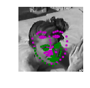

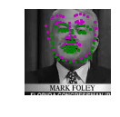

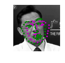

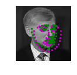

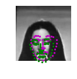

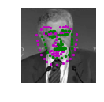

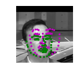

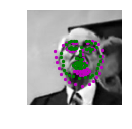

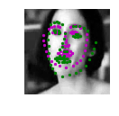

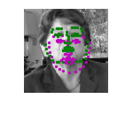

```python
## TODO: visualize your test output
# you can use the same function as before, by un-commenting the line below:

visualize_output(test_images, test_outputs, gt_pts)
```

Once you've found a good model (or two), save your model so you can load it and use it later!

Save your models but please **delete any checkpoints and saved models before you submit your project** otherwise your workspace may be too large to submit.

```python
## TODO: change the name to something uniqe for each new model
model_dir = 'saved_models/'
model_name = 'keypoints_model_3.pt'

# after training, save your model parameters in the dir 'saved_models'
torch.save(net.state_dict(), model_dir+model_name)
```

After you've trained a well-performing model, answer the following questions so that we have some insight into your training and architecture selection process. Answering all questions is required to pass this project.

### Question 1: What optimization and loss functions did you choose and why?

**Answer**: I chose MSELoss and Adam after reading the referenced paper by Agarwal et al becaue they got a good result and our tasks are very similar. And, the model seems to be learning albeit slowing town towards the 30th epoch.

### Question 2: What kind of network architecture did you start with and how did it change as you tried different architectures? Did you decide to add more convolutional layers or any layers to avoid overfitting the data?

**Answer**: I used 4 convolutional layers and 6 dropout layers like the paper.

### Question 3: How did you decide on the number of epochs and batch_size to train your model?

**Answer**: I tried 30 at first. And, I saw that the visualized results indicated that the model might be able to learn more, so I trained for 10 more epochs. I saw a slight improvement in scale invariance. So, I trained for 40 more epochs. I saw a much better scale invariance in the final model. I chose the batch size of 32 because I heard that it's most efficient to have a batch size value to be a power of 2. And, I heard that usually smaller the batch size is the better the accuracy is in many cases. So, I thought 32 might be okay.

## Feature Visualization

Sometimes, neural networks are thought of as a black box, given some input, they learn to produce some output. CNN's are actually learning to recognize a variety of spatial patterns and you can visualize what each convolutional layer has been trained to recognize by looking at the weights that make up each convolutional kernel and applying those one at a time to a sample image. This technique is called feature visualization and it's useful for understanding the inner workings of a CNN.

In the cell below, you can see how to extract a single filter (by index) from your first convolutional layer. The filter should appear as a grayscale grid.

```
[[-0.06614842  0.30586717  0.30494925  0.00062079]
 [ 0.26925245 -0.16648079  0.18645722  0.10601971]
 [ 0.0519628  -0.13037384 -0.03037712 -0.02323402]
 [-0.33059135 -0.31418458  0.00190937 -0.14977734]]
(4, 4)
```

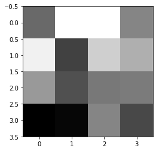

```python
# Get the weights in the first conv layer, "conv1"
# if necessary, change this to reflect the name of your first conv layer
weights1 = net.conv1.weight.data

w = weights1.numpy()

filter_index = 0

print(w[filter_index][0])
print(w[filter_index][0].shape)

# display the filter weights
plt.imshow(w[filter_index][0], cmap='gray')
```

## Feature maps

Each CNN has at least one convolutional layer that is composed of stacked filters (also known as convolutional kernels). As a CNN trains, it learns what weights to include in it's convolutional kernels and when these kernels are applied to some input image, they produce a set of **feature maps**. So, feature maps are just sets of filtered images; they are the images produced by applying a convolutional kernel to an input image. These maps show us the features that the different layers of the neural network learn to extract. For example, you might imagine a convolutional kernel that detects the vertical edges of a face or another one that detects the corners of eyes. You can see what kind of features each of these kernels detects by applying them to an image. One such example is shown below; from the way it brings out the lines in an the image, you might characterize this as an edge detection filter.

[figure not shown]

Next, choose a test image and filter it with one of the convolutional kernels in your trained CNN; look at the filtered output to get an idea what that particular kernel detects.

### TODO: Filter an image to see the effect of a convolutional kernel

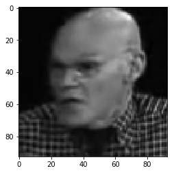

```python
##TODO: load in and display any image from the transformed test dataset
# un-transform the image data
image = test_images[0].data   # get the image from it's Variable wrapper
image = image.numpy()   # convert to numpy array from a Tensor
image = np.transpose(image, (1, 2, 0))   # transpose to go from torch to numpy image

plt.imshow(np.squeeze(image), cmap='gray')
```

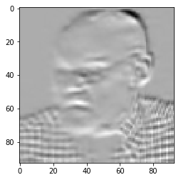

```python
import cv2

## TODO: Using cv's filter2D function,
## apply a specific set of filter weights (like the one displayed above) to the test image
filtered_1 = cv2.filter2D(image, -1, w[filter_index][0])
plt.imshow(filtered_1, cmap='gray')
```

[output not shown]

[figure not shown]

```python
# Get the weights in the first conv layer, "conv1"
# if necessary, change this to reflect the name of your first conv layer

filter_index = 5

print(w[filter_index][0])
print(w[filter_index][0].shape)

# display the filter weights
plt.imshow(w[filter_index][0], cmap='gray')
```

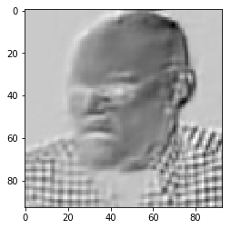

```python
import cv2

## TODO: Using cv's filter2D function,
## apply a specific set of filter weights (like the one displayed above) to the test image
filtered_1 = cv2.filter2D(image, -1, w[filter_index][0])
plt.imshow(filtered_1, cmap='gray')
```

```
[[ 0.09185228  0.05619231  0.0202594 ]
 [ 0.03620477 -0.03977945 -0.08957807]
 [ 0.09386917  0.0926953   0.02800984]]
(3, 3)
```

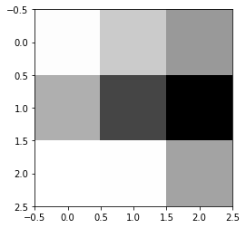

```python
import cv2

weights2 = net.conv2.weight.data

w = weights2.numpy()

filter_index = 0

print(w[filter_index][0])
print(w[filter_index][0].shape)

# display the filter weights
plt.imshow(w[filter_index][0], cmap='gray')
```

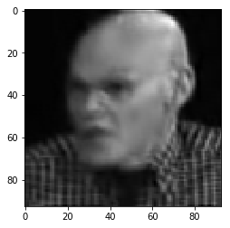

```python
## TODO: Using cv's filter2D function,
## apply a specific set of filter weights (like the one displayed above) to the test image
filtered_2 = cv2.filter2D(image, -1, w[filter_index][0])
plt.imshow(filtered_2, cmap='gray')
```

```
[[-0.08090819 -0.15211818]
 [-0.07329808 -0.01240921]]
(2, 2)
```

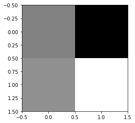

```python
weights3 = net.conv3.weight.data

w = weights3.numpy()

filter_index = 100

print(w[filter_index][0])
print(w[filter_index][0].shape)

# display the filter weights
plt.imshow(w[filter_index][0], cmap='gray')
```

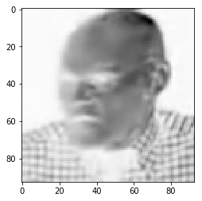

```python
filtered_3 = cv2.filter2D(image, -1, w[filter_index][0])
plt.imshow(filtered_3, cmap='gray')
```

### Question 4: Choose one filter from your trained CNN and apply it to a test image; what purpose do you think it plays? What kind of feature do you think it detects?

**Answer**: The very first filter seems to be detecting a horizontal lines of the face, like the horizontal line between the lips and the eye brows.

## Moving on!

Now that you've defined and trained your model (and saved the best model), you are ready to move on to the last notebook, which combines a face detector with your saved model to create a facial keypoint detection system that can predict the keypoints on *any* face in an image!